sceptre · methods recommendation

# Filter on the margins, not the interior: directional testability for pairwise QC

The current `n_nonzero_trt ≥ 7` rule filters on a quantity that is a proxy for the test statistic — so a strong knockdown fails QC *because* it worked. The fix: keep a pair only if its most favorable table could reach significance *in the direction you're testing*. Everything else is margins, and margins are ancillary.

Analysis for the sceptre maintainers· Ground-truth simulation + five real CRISPR screens

Recommendation

For each pair the margins are fixed and **ancillary**: the group sizes n_trt, n_cntrl and the number of cells expressing the gene, n_nonzero_tot. Ask the only question QC should ask — given those margins, could the **most favorable table** even reach significance, in the direction the test targets? If not, drop the pair.

p̄ = n_nonzero_tot / N // baseline detection rate (a margin) p_min = (1 − p̄)<sup>n_trt</sup> // best attainable KNOCKDOWN p (left-sided test) // two-sided: min over BOTH extreme tables keep pair ⇔ p_min ≤ α // α = the FDR level you run BH at

Because p_min is a function of the margins alone, it is independent of the test statistic under the null — calibration is preserved. Anchoring the bar at the FDR target α is **safe and non-circular**: a pair whose best case can't clear α can never be a BH discovery at level α, so dropping it never costs one. And the direction matters — a knockdown screen uses a one-sided test, so use the one-sided (knockdown) attainable p.

The mechanism today

## 1 How the current filter works

For each perturbation–gene pair, sceptre builds the 2×2 table of *{treatment, control}* against *{gene non-zero, gene zero}* and keeps the pair only if both non-zero counts clear a threshold (default `7`):

The 2×2 table. sceptre thresholds the two shaded cells of the non-zero column — *a* and *c*, both *interior* cells, symmetric, neither a margin.

|  | gene non-zero | gene zero | row margin |
| --- | --- | --- | --- |
| treatment (has gRNA) | **a** = n_nonzero_trt ≥ 7 | b | **n_trt** |
| control (NT / complement) | **c** = n_nonzero_cntrl ≥ 7 | d | n_cntrl |
| col. margin | a+c = n_nonzero_tot | b+d | N |

The stated intent is sound — sceptre's own documentation says the goal is to drop pairs "whose data are too sparse to be analyzed reliably." That is exactly what independent filtering is for. The problem is *which* quantity is thresholded.

Why it is circular

## 2 The treatment count is a shadow of the test statistic

sceptre's test statistic is a resampling score: with the gene's expression held fixed, it resamples *which cells carry the gRNA* and compares

z = ( Σ<sub>i∈trt</sub> a<sub>i</sub> ) / sd, a<sub>i</sub> = (y<sub>i</sub> − μ<sub>i</sub>) / (1 + μ<sub>i</sub>/θ) // NB residual

Now look at the filter quantity: `n_nonzero_trt = Σi∈trt 1{yi>0}`. It is a sum, over the very same treatment cells, of a per-cell expression signal — **the same functional form as the numerator of z**, with a coarse indicator in place of the residual. The filter is a low-resolution copy of the test statistic.

So the two move together. A strong knockdown drives `y→0` in the treatment cells; z becomes sharply negative *and* `n_nonzero_trt` falls — the pair is filtered out **because it shows the effect**. The rule is also directional: repression lowers the count, activation raises it, so it is biased against detecting repression — the primary readout of a CRISPRi screen. (The control count `c` is the symmetric interior cell; it escapes the same fate only because the control group is large, not because it is a margin.)

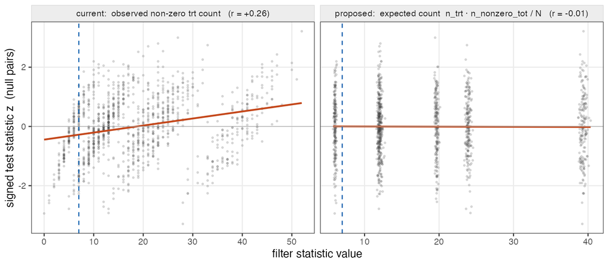

**The entanglement, on null pairs.** Each point is a null pair from a controlled simulation. **Left:** the current statistic `n_nonzero_trt` is correlated with the signed test statistic z (r = +0.26) — thresholding it at 7 (dashed) preferentially removes the negative-z repression tail. **Right:** the margin-based expected count is flat in z (r = −0.01): independent, as an admissible filter must be.

The principle

## 3 Independent filtering & testability

Bourgon, Gentleman & Huber ([PNAS 2010](https://www.pnas.org/doi/10.1073/pnas.0914005107)) formalized the two-stage recipe DESeq2 uses: filter on a statistic, then test only survivors. It preserves type-I / FDR control **iff the filter is marginally independent of the test statistic under the null**. Under the resampling, a statistic is ancillary — hence independent — exactly when it depends only on the fixed quantities: the gene's expression, the covariates, and the group sizes. **Margins qualify; interior cells do not.**

The sharpest margin-only filter is **testability** (Tarone, [Biometrics 1990](https://doi.org/10.2307/2531848); the engine behind significant-pattern-mining and discrete-FDR methods): a hypothesis whose *minimum attainable* p-value already exceeds the threshold can never be rejected, so removing it changes no rejection — it only shrinks the multiplicity. Applied to the 2×2 table, that minimum attainable p is a pure function of the margins.

The fix

## 4 Directional testability

Fix the margins; the table has one degree of freedom. Push it to the most favorable value and read off the hypergeometric (Fisher) tail — the minimum attainable p. For a knockdown that means all treatment cells zero, giving p_min = (1−p̄)<sup>n_trt</sup> with p̄ = n_nonzero_tot/N. Drop the pair iff even that best case can't clear α.

### It reverse-engineers the magic number 7

Take logs: `p_min ≤ δ` becomes `n_trt·(−ln(1−p̄)) ≥ ln(1/δ)`, and for small p̄ that is just `E[a] = n_trt·p̄ ≥ ln(1/δ)` — the expected non-zero count. So a fixed-count rule is the small-p̄ face of testability, and its threshold is `ln(1/δ)`. **sceptre's default of 7 is an implicit δ = e<sup>−7</sup> ≈ 9×10<sup>−4</sup>** — a per-test significance level nobody chose on purpose, and (see §5) one that usually sits *below* the BH threshold, so it over-filters.

### One number, not two

The current filter thresholds two cells, but in the margin framing the control side is redundant: `E[c] = n_cntrl·p̄ ≥ E[a]` whenever `n_cntrl ≥ n_trt` — always true, since control is the larger group. Verified: **0 of 1840** pairs bind on the control side once the treatment side passes. The "two knobs" were an artifact of thresholding the two *observed* cells, which a real effect decouples.

### Direction is the whole game

Take N = 1000 cells, a gene non-zero in **50 (5%)**, a guide in **n_trt = 20** cells. Under independence you'd expect only E[a] = 1 non-zero treatment cell. Push the free cell to each extreme:

▼ most extreme knockdown (a = 0)

|  | nonzero | zero |
| --- | --- | --- |
| treatment | 0 | 20 |
| control | 50 | 930 |

one-sided p = 0.36 — not testable

▲ most extreme activation (a = 20)

|  | nonzero | zero |
| --- | --- | --- |
| treatment | 20 | 0 |
| control | 30 | 950 |

one-sided p = 1.4×10<sup>−28</sup> — testable

It's a **floor effect**. The gene sits near zero, so there is almost no room to go *down* — the maximal knockdown moves you from ~1 expected non-zero cell to 0, a one-cell step that is completely unsurprising. But there is enormous room to go *up*: all 20 cells lighting up a gene that's off in 95% of cells is astronomically improbable by chance. So one-sided knockdown testability **drops** this pair (you cannot knock down a gene that's already off), while two-sided **keeps** it — for an activation a CRISPRi screen doesn't care about. Move the gene to 50% expressed and both extremes clear easily (p = 8×10<sup>−7</sup> each); the split only appears near a boundary.

**So match the filter's direction to the test's.** A left-sided knockdown screen uses the one-sided attainable p and filters meaningfully; a two-sided analysis uses the two-sided p, which legitimately removes almost nothing (most pairs can detect *something*) and leaves the multiplicity to BH.

### Choosing the threshold

The filter set at any δ is ancillary — known before any test, independent of the signal — so the only thing the signal touches is the *choice* of δ.

- **Default: δ = α** (the FDR target, e.g. 0.1). Safe and non-circular — a pair whose best case exceeds α can never be BH-rejected at α, so this only removes provably-hopeless pairs and weakly *raises* power. This is the recommended default.
- **More power, more machinery:** a tighter δ shrinks the multiplicity further, but the best δ sits just above the realized BH threshold — the one signal-dependent quantity, and the source of the circularity. Resolve it exactly via *Tarone's fixed point* (`k(δ)·δ ≤ α`, computed from the margins alone) for FWER, DESeq2-style optimization (sweep δ, maximize rejections) for a data-driven pick, or *discrete BH* (Döhler–Durand–Roquain 2018) to fold testability into the FDR step with no pre-filter at all.

Evidence · controlled simulation

## 5 What it buys, with ground truth

Real sceptre, run on simulated low-MOI data where every pair's knockdown strength κ is known, QC set permissive so every pair is tested and the filters applied afterward.

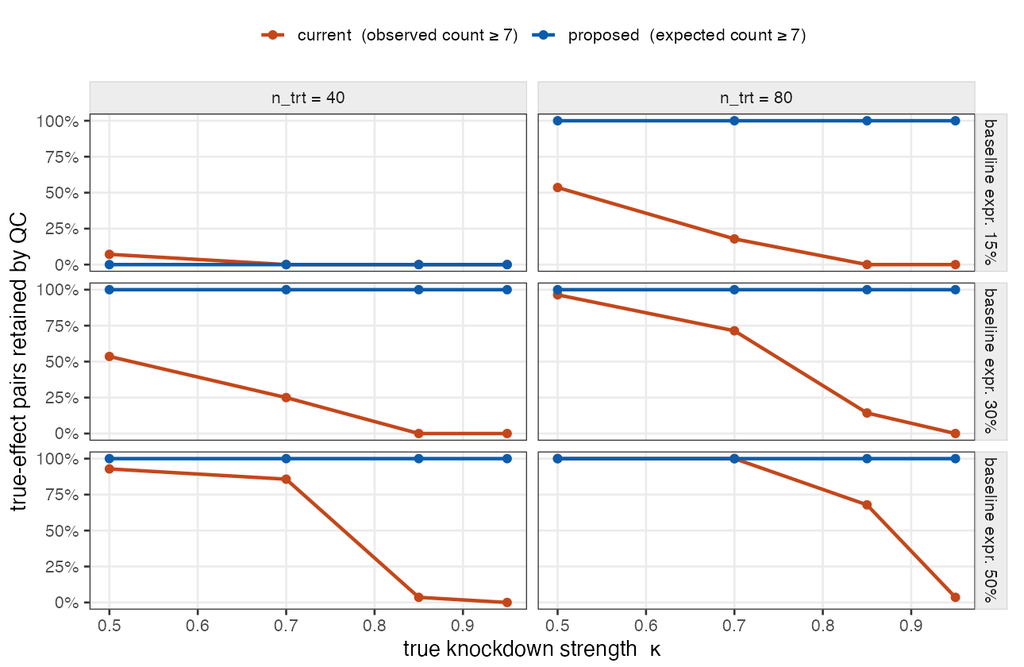

**The current filter discards true effects in proportion to how strong they are.** Fraction of genuine knockdowns retained, vs. strength κ, across baseline expression (rows) and treatment-cell count (columns). The current rule (orange) collapses toward zero as the effect strengthens; the margin-based filter (blue) is flat — dropping only the one genuinely underpowered cell.

True discoveries at BH-adjusted p < 0.1 (two-sided). The independence fix (observed→expected) does most of the work; relaxing the implicit δ from 7 to α recovers the rest. Realized FDR stays <10% throughout.

| filter | effective δ | true discoveries |
| --- | --- | --- |
| current (observed n_nonzero_trt ≥ 7) | — | 159 |
| expected count ≥ 7 (margin) | ≈ e<sup>−7</sup> = 9×10<sup>−4</sup> | 502 |
| directional testability, δ = α | 0.1 | 576 |

Calibration preserved · the "7" over-filters

Retained null p-values stay uniform under the margin filter (P(p<.05) = 0.051 vs 0.045 current). The realized BH threshold here is ≈ 0.03, so the current filter's implicit δ ≈ 9×10<sup>−4</sup> sits well below it — squarely in the over-filtering regime, discarding pairs that would have been discoveries.

Evidence · real screen, mechanism

## 6 The entanglement is real

On a real A549 CRISPRi screen (GSE236304), null (trans) pairs binned by each statistic show the same signature as the simulation:

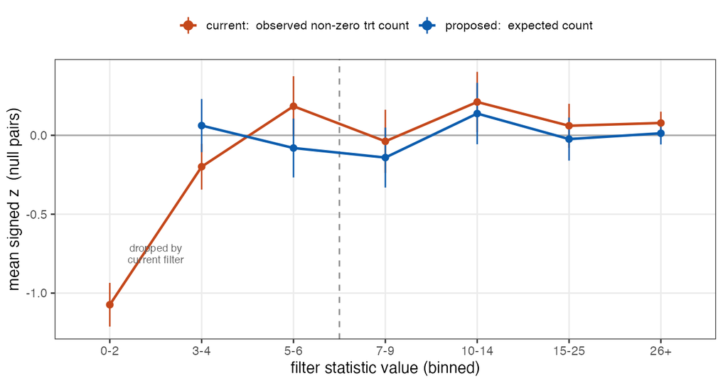

**Binning real null pairs by the current statistic sorts them by their test statistic.** Pairs the current filter would drop (`n_nonzero_trt` < 7) carry a mean z of −0.31 — down to −1.08 in the lowest bin, the repression tail. Binning by the expected count shows no gradient (r = +0.11 vs. +0.01).

Evidence · five real screens

## 7 How much it actually removes

Applying both filters to the full pair grids of five screens spanning MOI, depth, and library size:

Fraction of pairs dropped. "testability" is one-sided knockdown at δ = 0.1; the last column is the same at two-sided.

| screen | design | med. n_trt | pairs | current | testability 1-sided | 2-sided |
| --- | --- | --- | --- | --- | --- | --- |
| Replogle RD7 | low-MOI, genome-wide | 67 | 5.1M | 77.2% | 69.9% | 0.1% |
| a549 CRISPRi | high-MOI | 2007 | 1.9M | 44.2% | 37.5% | 0.0% |
| T-cell CD4 | low-MOI, sparse | 7 | 1.3M | 89.6% | 69.6% | 5.4% |
| dc-TAP K562 | low-MOI, focused | 651 | 279 | 8.6% | 7.5% | 0.0% |
| dc-TAP K562 | high-MOI, focused | 7995 | 279 | 5.4% | 3.6% | 0.0% |

Three things hold across all five. **(1) The drop fraction is large and dataset-driven** — in genome-wide or sparse-cell screens most pairs are genuinely untestable (Replogle's median gene is on in 0.1% of cells), so both filters remove 70–90%. Testability isn't a "keep everything" rule; a lot really is hopeless. **(2) Testability removes slightly fewer, and it's nearly one-way** — it drops ~0% of what the current rule keeps, while **rescuing 9–33%** of what the current rule drops. It's "current, minus the false drops," and the gap is widest where cells-per-guide is smallest, exactly where the strict "7" bites hardest. **(3) Two-sided removes almost nothing** — the multiplicity then falls entirely on BH.

Safe on gold-standard knockdowns

On Replogle's 717 strong self-targeting positive controls (median log₂FC = −2.99, ~8× repression), the two filters agree completely — all kept, identical 683 discoveries. Where pairs are well-powered the fix is a no-op; it changes decisions only near the boundary, and in the right direction.

Implementation

## 8 The change to sceptre

`compute_pairwise_qc_information()` already returns `n_nonzero_trt` and `n_nonzero_cntrl` (their sum is the column margin); the only additions are the group sizes n_trt and n_cntrl, which the C++ has in hand. Then `compute_qc_metrics()` becomes a directional testability check:

```
# R/pairwise_qc_functs.R — compute_qc_metrics()
- pass_qc = (n_nonzero_trt  >= n_nonzero_trt_thresh &
-            n_nonzero_cntrl >= n_nonzero_cntrl_thresh)
+ p_bar  = (n_nonzero_trt + n_nonzero_cntrl) / (n_trt + n_cntrl)   # detection rate (margin)
+ p_down = stats::phyper(0, m = n_nonzero_trt + n_nonzero_cntrl,   # best attainable knockdown p
+                        n = (n_trt + n_cntrl) - (n_nonzero_trt + n_nonzero_cntrl), k = n_trt)
+ p_up   = stats::phyper(n_trt - 1, m = n_nonzero_trt + n_nonzero_cntrl,
+                        n = (n_trt + n_cntrl) - (n_nonzero_trt + n_nonzero_cntrl),
+                        k = n_trt, lower.tail = FALSE)             # best attainable activation p
+ p_min  = switch(side, left = p_down, right = p_up, both = pmin(1, 2*pmin(p_down, p_up)))
+ pass_qc = (p_min <= alpha)                                        # alpha = multiple_testing_alpha
```

The knob changes from a hard-coded count to the FDR level α the analysis already carries (`multiple_testing_alpha`), and it respects the analysis's `side`. Keep the observed `n_nonzero_trt` in the results table as a diagnostic; just stop *gating* on it. For the extra multiplicity margin, expose an `independent_filtering = TRUE` option that sweeps δ DESeq2-style.

Caveats

## 9 Where to be careful

- **Two-sided filters little.** That's correct, not a bug — a pair that could detect a large activation *is* testable two-sided. If you want QC to shrink the multiplicity in a two-sided analysis you must move to a tighter δ (with the circularity), because a valid filter can't remove pairs that are genuinely testable.
- **It's a proxy for the real test.** sceptre's test is the covariate-adjusted resampling score test, not Fisher's exact; the hypergeometric p_min is a fast closed-form stand-in for attainability. It is a valid (ancillary) filter regardless; for exactness you'd compute the minimum attainable p under sceptre's own resampling.
- **Null reliability** (as opposed to power) is governed by the total non-zero count n_nonzero_tot — largely implied, since low-total pairs are also low-power, but a light explicit floor is cheap insurance if the resampling tail worries you.

**Reproducibility.** sceptre 0.99.0, permutation resampling. The simulation calls sceptre end-to-end on data with known per-pair knockdown strength; real screens are Replogle RD7 (genome-wide K562, ~93M pairs), A549 (GSE236304), CD4 T-cell (GSE314342), and dc-TAP K562 low/high-MOI (GSE303901). Filter: current = observed `n_nonzero_trt`; proposed = minimum attainable hypergeometric p given the margins, in the test's direction, compared to the FDR level. Scripts and build instructions are in `writeups/pairwise-qc/`.

References: Bourgon, Gentleman & Huber, PNAS 107:9546 (2010); Tarone, Biometrics 46:515 (1990); Döhler, Durand & Roquain, Electron. J. Statist. 12:1023 (2018).